# Logisitic Regression Workbook and Assignment

## Set Up

To set up lets first load the packages which we will use for the analysis. These are `ggplot2`, `reshape2`, `plotmo`, and `glmnet`

```r
# Uncomment below lines to install packages
# install.packages("ggplot2"") # Install ggplot2
# install.packages("reshape") # Install reshape2
# install.packages("glmnet") # Install glmnet
# install.packages("plotmo")
library(ggplot2) # load ggplot
library(reshape) # load reshape 2
library(glmnet) # Load glmnet
library(plotmo) # for plot_glmnet
```

For this analysis we will be analyzing breast cancer data. Worldwide, breast cancer is the most common type of cancer in women and the second highest in terms of mortality rates. Diagnosis of breast cancer is performed when an abnormal lump is found (from self-examination or x-ray) or a tiny speck of calcium is seen (on an x-ray). After a suspicious lump is found, the doctor will conduct a diagnosis to determine whether it is cancerous and, if so, whether it has spread to other parts of the body.

The objective of this analysis is to use tumor features to identify malignant tumors. Lets load out dataset into the working environment. It is called `breast_cancer_data.rda`. To load it in with the below command ensure your working directory is set to the file location. Alternatively you can use file->open file and then navigate to where the file is and load it in using that method.

```r
load("breast_cancer_data.rda")
```

```r
head(bc_data) # View first five rows
```

```
##   mean_radius mean_texture mean_perimeter mean_area mean_smoothness diagnosis
## 1       17.99        10.38         122.80    1001.0         0.11840         0
## 2       20.57        17.77         132.90    1326.0         0.08474         0
## 3       19.69        21.25         130.00    1203.0         0.10960         0
## 4       11.42        20.38          77.58     386.1         0.14250         0
## 5       20.29        14.34         135.10    1297.0         0.10030         0
## 6       12.45        15.70          82.57     477.1         0.12780         0
```

```r
tail(bc_data) # View last five rows
```

```
##     mean_radius mean_texture mean_perimeter mean_area mean_smoothness diagnosis
## 564       20.92        25.09         143.00    1347.0         0.10990         0
## 565       21.56        22.39         142.00    1479.0         0.11100         0
## 566       20.13        28.25         131.20    1261.0         0.09780         0
## 567       16.60        28.08         108.30     858.1         0.08455         0
## 568       20.60        29.33         140.10    1265.0         0.11780         0
## 569        7.76        24.54          47.92     181.0         0.05263         1
```

```r
dim(bc_data) # View dimension
```

```
## [1] 569   6
```

For this analysis we have 569 observations and 6 variables. The variables we have available for this analysis are:

- mean_radius - Mean distance from center of tumor to perimeter of tumor
- mean_texture - Standard deviation of grey-scale image of tumor
- mean_perimeter - Mean size of the core tumor
- mean_area - Mean area of the core tumor
- mean_smoothness - Mean of local variation in radius lengths
- diagnosis - 1/0 indicating malignant/benign

For this we will use the diagnosis variable as our response and the remaining variables as our explanatory variables. The other variables refer to the characteristics of the tumor in the image. The objective of this analysis is to identify characteristics of the images that can be used to identify malignant tumors.

## Analyse Data

As a preliminary analysis we can visualize how the features vary for malignant and benign tumors. To do this we can use density plots to view the different distributions for each feature for malignant and benign tumors.

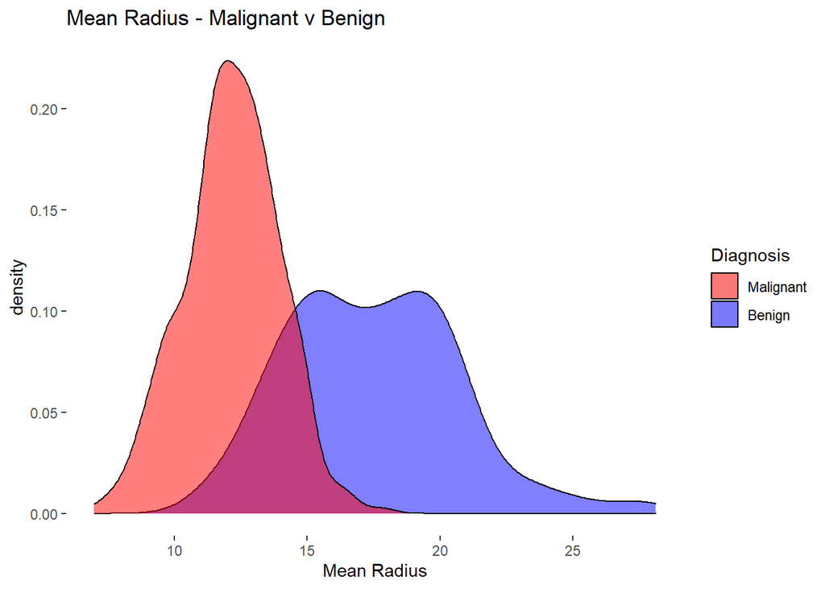

```r
# Do densities
plot_dat <- bc_data # Create data to use as plot data
plot_dat$diagnosis <- as.factor(plot_dat$diagnosis) # Convert response to factor for plotting
g_1 <- ggplot(plot_dat, aes(x = mean_radius, fill = diagnosis)) + # Set x as mean radius and fill as diagnosis
  geom_density(alpha = 0.5) + # Select density plot and set transperancy (alpha)
    theme_set(theme_bw(base_size = 22) ) + # Set theme and text size
  theme(panel.grid.major = element_blank(), # Remove grid
        panel.grid.minor = element_blank(), # Remove grid
        panel.border = element_blank(), # Remove grid
        panel.background = element_blank()) + # Remove grid
  labs(x = "Mean Radius", title = "Mean Radius - Malignant v Benign",
       fill = "Diagnosis") + # Set labels
  scale_fill_manual(values = c("1" = "red", "0" = "blue"), # Set fill colors manually
                    labels = c("1" = "Malignant", "0" = "Benign")) # Set labels for fill
g_1 # Generate plot
```

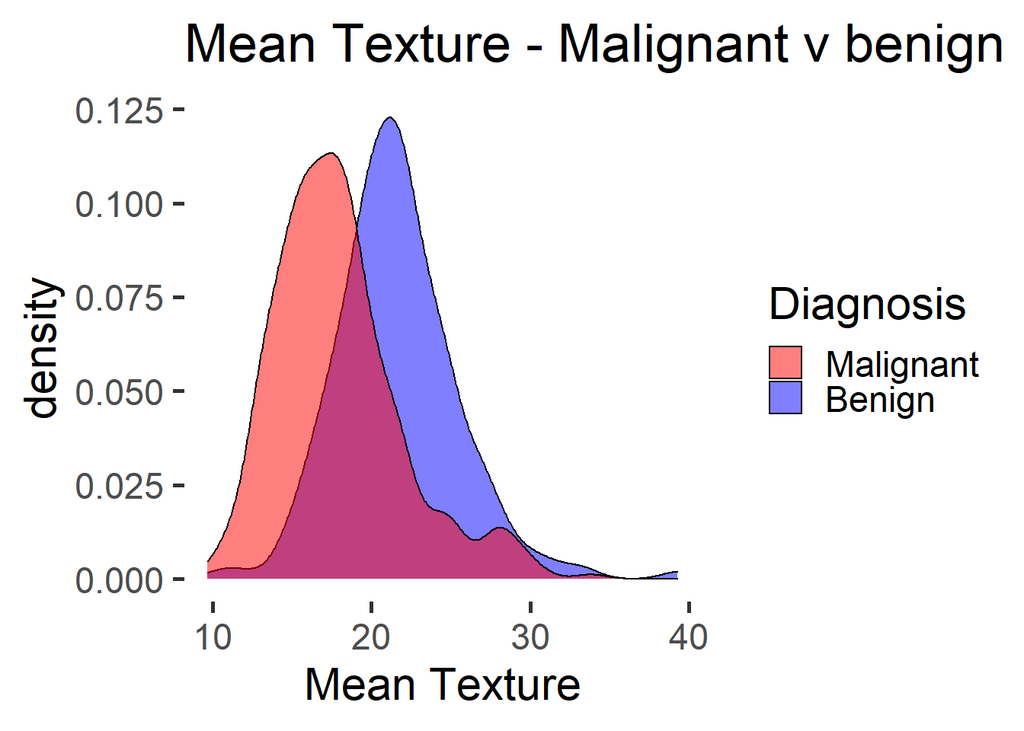

```r
g_2 <- ggplot(plot_dat, aes(x = mean_texture, fill = diagnosis)) + # Set x as mean texture and fill as diagnosis
  geom_density(alpha = 0.5) + # Select density plot and set transperancy (alpha)
    theme_set(theme_bw(base_size = 22) ) + # Set theme and text size
  theme(panel.grid.major = element_blank(), # Remove grid
        panel.grid.minor = element_blank(), # Remove grid
        panel.border = element_blank(), # Remove grid
        panel.background = element_blank()) + # Remove grid
  labs(x = "Mean Texture", title = "Mean Texture - Malignant v benign",
       fill = "Diagnosis") + # Set labels
  scale_fill_manual(values = c("1" = "red", "0" = "blue"), # Set fill colors manually
                    labels = c("1" = "Malignant", "0" = "Benign")) # Set labels for fill
g_2 # Generate plot
```

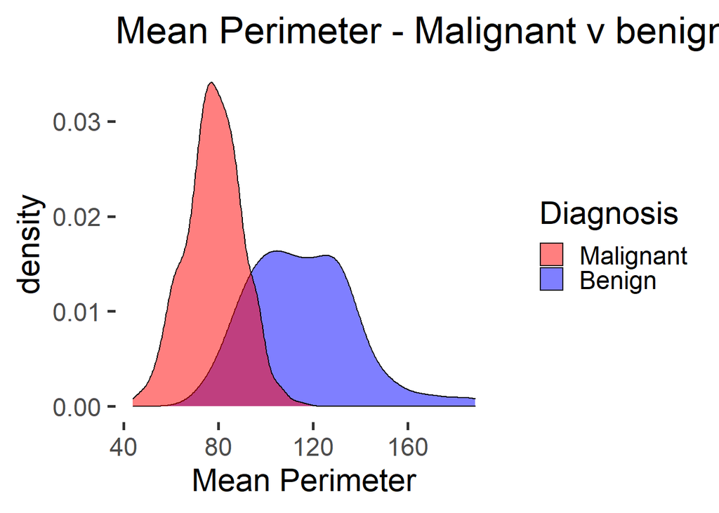

```r
g_3 <- ggplot(plot_dat, aes(x = mean_perimeter, fill = diagnosis)) + # Set x as mean perimeter and fill as diagnosis
  geom_density(alpha = 0.5) + # Select density plot and set transperancy (alpha)
    theme_set(theme_bw(base_size = 22) ) + # Set theme and text size
  theme(panel.grid.major = element_blank(), # Remove grid
        panel.grid.minor = element_blank(), # Remove grid
        panel.border = element_blank(), # Remove grid
        panel.background = element_blank()) + # Remove grid
  labs(x = "Mean Perimeter", title = "Mean Perimeter - Malignant v benign",
       fill = "Diagnosis") + # Set labels
  scale_fill_manual(values = c("1" = "red", "0" = "blue"), # Set fill colors manually
                    labels = c("1" = "Malignant", "0" = "Benign")) # Set labels for fill
g_3 # Generate plot
```

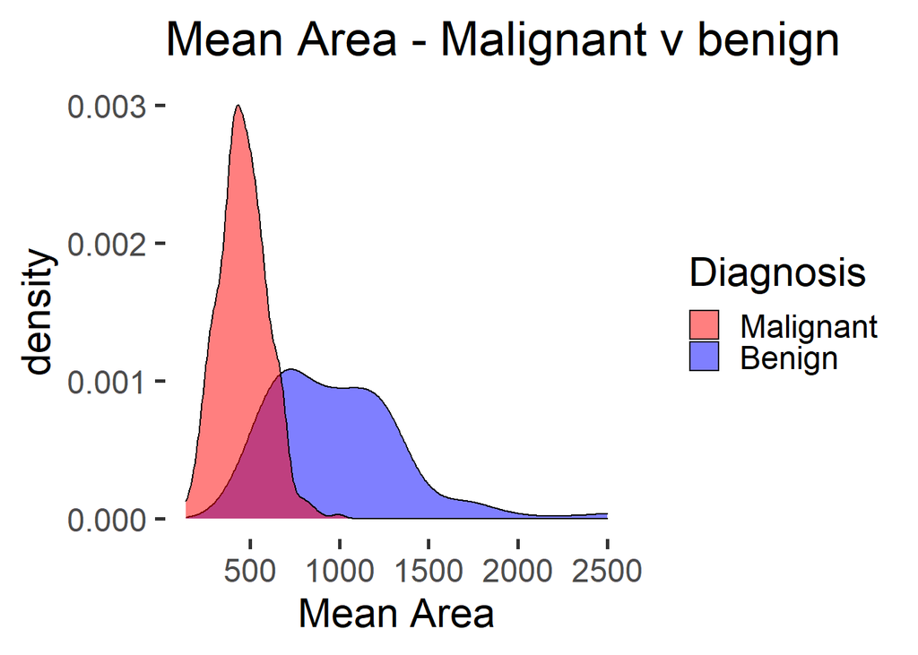

```r
g_4 <- ggplot(plot_dat, aes(x = mean_area, fill = diagnosis)) + # Set x as mean area and fill as diagnosis
  geom_density(alpha = 0.5) + # Select density plot and set transperancy (alpha)
    theme_set(theme_bw(base_size = 22) ) + # Set theme and text size
  theme(panel.grid.major = element_blank(), # Remove grid
        panel.grid.minor = element_blank(), # Remove grid
        panel.border = element_blank(), # Remove grid
        panel.background = element_blank()) + # Remove grid
  labs(x = "Mean Area", title = "Mean Area - Malignant v benign",
       fill = "Diagnosis") + # Set labels
  scale_fill_manual(values = c("1" = "red", "0" = "blue"), # Set fill colors manually
                    labels = c("1" = "Malignant", "0" = "Benign")) # Set labels for fill
g_4 # Generate plot
```

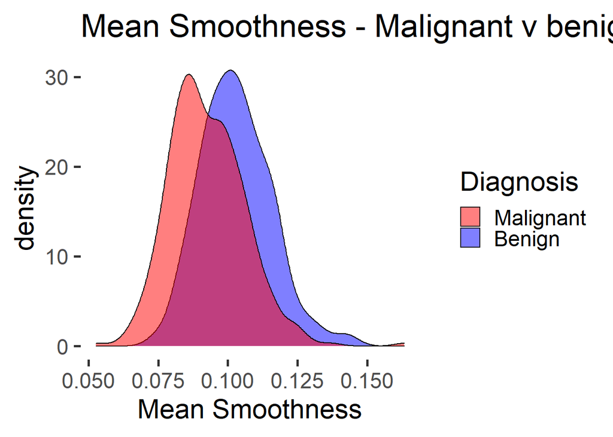

```r
g_5 <- ggplot(plot_dat, aes(x = mean_smoothness, fill = diagnosis)) + # Set x as mean smoothness and fill as diagnosis
  geom_density(alpha = 0.5) + # Select density plot and set transperancy (alpha)
    theme_set(theme_bw(base_size = 22) ) + # Set theme and text size
  theme(panel.grid.major = element_blank(), # Remove grid
        panel.grid.minor = element_blank(), # Remove grid
        panel.border = element_blank(), # Remove grid
        panel.background = element_blank()) + # Remove grid
  labs(x = "Mean Smoothness", title = "Mean Smoothness - Malignant v benign",
       fill = "Diagnosis") + # Set labels
  scale_fill_manual(values = c("1" = "red", "0" = "blue"), # Set fill colors manually
                    labels = c("1" = "Malignant", "0" = "Benign")) # Set labels for fill
g_5 # Generate plot
```

From the density plots we can see that in general the radius, perimeter and area of malignant tumors is generally smaller than benign. Similarly the texture and smoothness variables are generally smaller for malignant tumors though the separation is not as clear as for the other three variables. Another way we can visualize all of the variables at the same time is to use `geom_boxplot()` and `facet_wrap()` to create five plots on the same chart where we can view the differences for all variables at once.

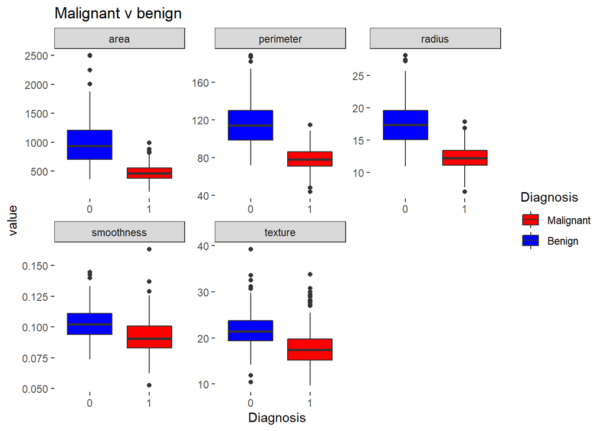

```r
m_dat <- melt(plot_dat, id.vars = "diagnosis") # Melt data to long form
m_dat$var_2 <- rep("radius", nrow(m_dat)) # Create nicer vector to store feature names
m_dat$var_2[which(m_dat$variable == "mean_texture")] <- "texture"
m_dat$var_2[which(m_dat$variable == "mean_perimeter")] <- "perimeter"
m_dat$var_2[which(m_dat$variable == "mean_area")] <- "area"
m_dat$var_2[which(m_dat$variable == "mean_smoothness")] <- "smoothness"

g_6 <- ggplot(m_dat, aes( y = value, x = diagnosis, fill = diagnosis)) + # Set x and fill as disagnosis, y as value
  geom_boxplot() + # Use boxlot
  facet_wrap(~var_2, scales = "free") + # Create small multiples
    theme_bw() + # Set theme
  theme(panel.grid.major = element_blank(), # Remove grid
        panel.grid.minor = element_blank(), # Remove grid
        panel.border = element_blank(), # Remove grid
        panel.background = element_blank()) + # Remove grid
  labs(x = "Diagnosis", title = "Malignant v benign",
       fill = "Diagnosis") + # Set labels
  scale_fill_manual(values = c("1" = "red", "0" = "blue"), # Manually set fill values
                    labels = c("1" = "Malignant", "0" = "Benign"))
g_6 # Generate plot
```

The boxplots confirm our initial observations for the predictive power of the variables with malignant tumors generally having smaller values for all of the variables.

## Logistic Regression

As we are working with a binary response we will use logistic regression for this analysis. We run a logistic regression using the `glm()` function, as logistic regression is a generalized linear model. To select linear regression we set our link function by setting `family = binomial(link = logit)` Lets try single variable logistic regressions first:

```r
# Try mean area
fit_1 <- glm(diagnosis ~ mean_area, # Set formula
             family=binomial(link='logit'), # Set logistic regression
             data= bc_data) # Set dataset
summary(fit_1) # Sumamrize model
```

```
##
## Call:
## glm(formula = diagnosis ~ mean_area, family = binomial(link = "logit"),
##     data = bc_data)
##
## Deviance Residuals:
##      Min        1Q    Median        3Q       Max
## -2.73598  -0.09862   0.20420   0.46420   2.72957
##
## Coefficients:
##             Estimate Std. Error z value Pr(>|z|)
## (Intercept)  7.97409    0.68286   11.68   <2e-16 ***
## mean_area   -0.01177    0.00109  -10.80   <2e-16 ***
## ---
## Signif. codes:  0 '***' 0.001 '**' 0.01 '*' 0.05 '.' 0.1 ' ' 1
##
## (Dispersion parameter for binomial family taken to be 1)
##
##     Null deviance: 751.44  on 568  degrees of freedom
## Residual deviance: 325.66  on 567  degrees of freedom
## AIC: 329.66
##
## Number of Fisher Scoring iterations: 7
```

```r
# Try mean perimeter
fit_2 <- glm(diagnosis ~ mean_perimeter, # Set formula
             family=binomial(link='logit'), # Set logistic
             data= bc_data) # Set dataset
summary(fit_2) # Sumamrize model
```

```
##
## Call:
## glm(formula = diagnosis ~ mean_perimeter, family = binomial(link = "logit"),
##     data = bc_data)
##
## Deviance Residuals:
##     Min       1Q   Median       3Q      Max
## -2.8080  -0.1238   0.1525   0.4228   2.4998
##
## Coefficients:
##                Estimate Std. Error z value Pr(>|z|)
## (Intercept)    15.71333    1.37476   11.43   <2e-16 ***
## mean_perimeter -0.16399    0.01485  -11.04   <2e-16 ***
## ---
## Signif. codes:  0 '***' 0.001 '**' 0.01 '*' 0.05 '.' 0.1 ' ' 1
##
## (Dispersion parameter for binomial family taken to be 1)
##
##     Null deviance: 751.44  on 568  degrees of freedom
## Residual deviance: 304.48  on 567  degrees of freedom
## AIC: 308.48
##
## Number of Fisher Scoring iterations: 7
```

```r
# Try mean radius
fit_3 <- glm(diagnosis ~ mean_radius, # Set formula
             family=binomial(link='logit'), # Set logistic regression
             data= bc_data) # Set dataset
summary(fit_3) # Sumamrize model
```

```
##
## Call:
## glm(formula = diagnosis ~ mean_radius, family = binomial(link = "logit"),
##     data = bc_data)
##
## Deviance Residuals:
##     Min       1Q   Median       3Q      Max
## -2.8098  -0.1513   0.1746   0.4694   2.5470
##
## Coefficients:
##             Estimate Std. Error z value Pr(>|z|)
## (Intercept) 15.24587    1.32463   11.51   <2e-16 ***
## mean_radius -1.03359    0.09311  -11.10   <2e-16 ***
## ---
## Signif. codes:  0 '***' 0.001 '**' 0.01 '*' 0.05 '.' 0.1 ' ' 1
##
## (Dispersion parameter for binomial family taken to be 1)
##
##     Null deviance: 751.44  on 568  degrees of freedom
## Residual deviance: 330.01  on 567  degrees of freedom
## AIC: 334.01
##
## Number of Fisher Scoring iterations: 6
```

```r
# Try mean smoothness
fit_4 <- glm(diagnosis ~ mean_smoothness, # Set formula
             family=binomial(link='logit'), # Set logistic regression
             data= bc_data) # Set dataset
summary(fit_4) # Sumamrize model
```

```
##
## Call:
## glm(formula = diagnosis ~ mean_smoothness, family = binomial(link = "logit"),
##     data = bc_data)
##
## Deviance Residuals:
##     Min       1Q   Median       3Q      Max
## -2.0404  -1.1428   0.6357   0.9148   2.6352
##
## Coefficients:
##                 Estimate Std. Error z value Pr(>|z|)
## (Intercept)       6.3773     0.7474   8.532  < 2e-16 ***
## mean_smoothness -60.0857     7.5497  -7.959 1.74e-15 ***
## ---
## Signif. codes:  0 '***' 0.001 '**' 0.01 '*' 0.05 '.' 0.1 ' ' 1
##
## (Dispersion parameter for binomial family taken to be 1)
##
##     Null deviance: 751.44  on 568  degrees of freedom
## Residual deviance: 673.95  on 567  degrees of freedom
## AIC: 677.95
##
## Number of Fisher Scoring iterations: 3
```

```r
# Try mean texture
fit_5 <- glm(diagnosis ~ mean_texture, # Set formula
             family=binomial(link='logit'), # Set logistic regression
             data= bc_data) # Set dataset
summary(fit_5) # Sumamrize model
```

```
##
## Call:
## glm(formula = diagnosis ~ mean_texture, family = binomial(link = "logit"),
##     data = bc_data)
##
## Deviance Residuals:
##     Min       1Q   Median       3Q      Max
## -2.3477  -1.1022   0.5881   0.8451   2.3942
##
## Coefficients:
##              Estimate Std. Error z value Pr(>|z|)
## (Intercept)   5.12577    0.52638   9.738   <2e-16 ***
## mean_texture -0.23464    0.02614  -8.975   <2e-16 ***
## ---
## Signif. codes:  0 '***' 0.001 '**' 0.01 '*' 0.05 '.' 0.1 ' ' 1
##
## (Dispersion parameter for binomial family taken to be 1)
##
##     Null deviance: 751.44  on 568  degrees of freedom
## Residual deviance: 646.52  on 567  degrees of freedom
## AIC: 650.52
##
## Number of Fisher Scoring iterations: 4
```

The AIC for our single variable models is as follows:

- mean_radius - 334.01
- mean_texture - 650.52
- mean_perimeter - 308.48
- mean_area - 329.66
- mean_smoothness - 677.95

Therefore if we were to select just a single variable to use for predicting malignant/benign tumors, the best model and feature to use would be `mean_perimeter`.

To examine the AIC lets add our variables one at a time to the model in order of their univariate AIC.

```r
fit_6 <- glm(diagnosis ~ mean_perimeter , # Set formula
             family=binomial(link='logit'),# Set logistic Regression
             data= bc_data) # Set dataset
summary(fit_6) # Sumamrize model
```

```
##
## Call:
## glm(formula = diagnosis ~ mean_perimeter, family = binomial(link = "logit"),
##     data = bc_data)
##
## Deviance Residuals:
##     Min       1Q   Median       3Q      Max
## -2.8080  -0.1238   0.1525   0.4228   2.4998
##
## Coefficients:
##                Estimate Std. Error z value Pr(>|z|)
## (Intercept)    15.71333    1.37476   11.43   <2e-16 ***
## mean_perimeter -0.16399    0.01485  -11.04   <2e-16 ***
## ---
## Signif. codes:  0 '***' 0.001 '**' 0.01 '*' 0.05 '.' 0.1 ' ' 1
##
## (Dispersion parameter for binomial family taken to be 1)
##
##     Null deviance: 751.44  on 568  degrees of freedom
## Residual deviance: 304.48  on 567  degrees of freedom
## AIC: 308.48
##
## Number of Fisher Scoring iterations: 7
```

```r
fit_7 <- glm(diagnosis ~ mean_perimeter + mean_area , # Set formula
             family=binomial(link='logit'),# Set logistic Regression
             data= bc_data) # Set dataset
summary(fit_7) # Sumamrize model
```

```
##
## Call:
## glm(formula = diagnosis ~ mean_perimeter + mean_area, family = binomial(link = "logit"),
##     data = bc_data)
##
## Deviance Residuals:
##      Min        1Q    Median        3Q       Max
## -2.94411  -0.23527   0.09279   0.36746   2.20383
##
## Coefficients:
##                 Estimate Std. Error z value Pr(>|z|)
## (Intercept)    28.122257   3.613765   7.782 7.14e-15 ***
## mean_perimeter -0.432841   0.069317  -6.244 4.25e-10 ***
## mean_area       0.019724   0.004582   4.305 1.67e-05 ***
## ---
## Signif. codes:  0 '***' 0.001 '**' 0.01 '*' 0.05 '.' 0.1 ' ' 1
##
## (Dispersion parameter for binomial family taken to be 1)
##
##     Null deviance: 751.44  on 568  degrees of freedom
## Residual deviance: 290.24  on 566  degrees of freedom
## AIC: 296.24
##
## Number of Fisher Scoring iterations: 6
```

```r
fit_8 <- glm(diagnosis ~ mean_radius  + mean_perimeter + mean_area, # Set formula
             family=binomial(link='logit'),# Set logistic Regression
             data= bc_data) # Set dataset
summary(fit_8) # Sumamrize model
```

```
##
## Call:
## glm(formula = diagnosis ~ mean_radius + mean_perimeter + mean_area,
##     family = binomial(link = "logit"), data = bc_data)
##
## Deviance Residuals:
##      Min        1Q    Median        3Q       Max
## -2.80074  -0.01829   0.16236   0.32517   3.11112
##
## Coefficients:
##                Estimate Std. Error z value Pr(>|z|)
## (Intercept)    -7.10412    6.03037  -1.178  0.23877
## mean_radius     9.07843    1.42769   6.359 2.03e-10 ***
## mean_perimeter -1.08267    0.14640  -7.396 1.41e-13 ***
## mean_area      -0.03376    0.01065  -3.170  0.00152 **
## ---
## Signif. codes:  0 '***' 0.001 '**' 0.01 '*' 0.05 '.' 0.1 ' ' 1
##
## (Dispersion parameter for binomial family taken to be 1)
##
##     Null deviance: 751.44  on 568  degrees of freedom
## Residual deviance: 240.94  on 565  degrees of freedom
## AIC: 248.94
##
## Number of Fisher Scoring iterations: 8
```

```r
fit_9 <- glm(diagnosis ~ mean_radius + mean_texture + mean_perimeter + mean_area, # Set formula
             family=binomial(link='logit'),# Set logistic Regression
             data= bc_data) # Set dataset
summary(fit_9) # Sumamrize model
```

```
##
## Call:
## glm(formula = diagnosis ~ mean_radius + mean_texture + mean_perimeter +
##     mean_area, family = binomial(link = "logit"), data = bc_data)
##
## Deviance Residuals:
##     Min       1Q   Median       3Q      Max
## -2.9614  -0.0181   0.1234   0.2664   3.2262
##
## Coefficients:
##                Estimate Std. Error z value Pr(>|z|)
## (Intercept)    -1.77291    6.87011  -0.258  0.79636
## mean_radius     9.42874    1.63958   5.751 8.89e-09 ***
## mean_texture   -0.23761    0.04603  -5.162 2.44e-07 ***
## mean_perimeter -1.15066    0.16436  -7.001 2.54e-12 ***
## mean_area      -0.03277    0.01182  -2.771  0.00558 **
## ---
## Signif. codes:  0 '***' 0.001 '**' 0.01 '*' 0.05 '.' 0.1 ' ' 1
##
## (Dispersion parameter for binomial family taken to be 1)
##
##     Null deviance: 751.44  on 568  degrees of freedom
## Residual deviance: 211.37  on 564  degrees of freedom
## AIC: 221.37
##
## Number of Fisher Scoring iterations: 8
```

```r
fit_10 <- glm(diagnosis ~ mean_radius + mean_texture + mean_perimeter + mean_area +  mean_smoothness, # Set formula
             family=binomial(link='logit'),# Set logistic Regression
             data= bc_data) # Set dataset
summary(fit_10) # Sumamrize model
```

```
##
## Call:
## glm(formula = diagnosis ~ mean_radius + mean_texture + mean_perimeter +
##     mean_area + mean_smoothness, family = binomial(link = "logit"),
##     data = bc_data)
##
## Deviance Residuals:
##      Min        1Q    Median        3Q       Max
## -2.95825  -0.00647   0.05077   0.18661   1.99058
##
## Coefficients:
##                   Estimate Std. Error z value Pr(>|z|)
## (Intercept)       12.52617    8.38544   1.494 0.135228
## mean_radius        6.27525    1.83569   3.418 0.000630 ***
## mean_texture      -0.36410    0.06004  -6.064 1.33e-09 ***
## mean_perimeter    -0.60716    0.17944  -3.384 0.000715 ***
## mean_area         -0.04178    0.01375  -3.038 0.002378 **
## mean_smoothness -118.46210   20.64837  -5.737 9.63e-09 ***
## ---
## Signif. codes:  0 '***' 0.001 '**' 0.01 '*' 0.05 '.' 0.1 ' ' 1
##
## (Dispersion parameter for binomial family taken to be 1)
##
##     Null deviance: 751.44  on 568  degrees of freedom
## Residual deviance: 169.22  on 563  degrees of freedom
## AIC: 181.22
##
## Number of Fisher Scoring iterations: 8
```

For these we can see that each of the features added demonstrates enough predictive power to justify its inclusion in the model with the AIC continuing to fall as we add features to the model. Lets try add some noise variables and see what happens to the AIC

```r
bc_data$noise_1 <- rnorm(n = nrow(bc_data))
bc_data$noise_2 <- rnorm(n = nrow(bc_data))
bc_data$noise_3 <- rnorm(n = nrow(bc_data))
bc_data$noise_4 <- rnorm(n = nrow(bc_data))
bc_data$noise_5 <- rnorm(n = nrow(bc_data))
fit_11 <- glm(diagnosis ~ mean_radius + mean_texture + mean_perimeter + mean_area +  mean_smoothness +noise_1, # Set formula
             family=binomial(link='logit'),# Set logistic Regression
             data= bc_data) # Set dataset
summary(fit_11) # Sumamrize model
```

```
##
## Call:
## glm(formula = diagnosis ~ mean_radius + mean_texture + mean_perimeter +
##     mean_area + mean_smoothness + noise_1, family = binomial(link = "logit"),
##     data = bc_data)
##
## Deviance Residuals:
##      Min        1Q    Median        3Q       Max
## -2.95600  -0.00646   0.05079   0.18595   1.99673
##
## Coefficients:
##                   Estimate Std. Error z value Pr(>|z|)
## (Intercept)      1.252e+01  8.388e+00   1.492 0.135667
## mean_radius      6.272e+00  1.838e+00   3.412 0.000644 ***
## mean_texture    -3.642e-01  6.014e-02  -6.057 1.39e-09 ***
## mean_perimeter  -6.063e-01  1.810e-01  -3.350 0.000807 ***
## mean_area       -4.181e-02  1.378e-02  -3.035 0.002409 **
## mean_smoothness -1.185e+02  2.064e+01  -5.738 9.59e-09 ***
## noise_1         -6.849e-03  1.867e-01  -0.037 0.970744
## ---
## Signif. codes:  0 '***' 0.001 '**' 0.01 '*' 0.05 '.' 0.1 ' ' 1
##
## (Dispersion parameter for binomial family taken to be 1)
##
##     Null deviance: 751.44  on 568  degrees of freedom
## Residual deviance: 169.22  on 562  degrees of freedom
## AIC: 183.22
##
## Number of Fisher Scoring iterations: 8
```

```r
fit_12 <- glm(diagnosis ~ mean_radius + mean_texture + mean_perimeter + mean_area +  mean_smoothness +noise_1 + noise_2, # Set formula
             family=binomial(link='logit'),# Set logistic Regression
             data= bc_data) # Set dataset
summary(fit_12) # Sumamrize model
```

```
##
## Call:
## glm(formula = diagnosis ~ mean_radius + mean_texture + mean_perimeter +
##     mean_area + mean_smoothness + noise_1 + noise_2, family = binomial(link = "logit"),
##     data = bc_data)
##
## Deviance Residuals:
##      Min        1Q    Median        3Q       Max
## -2.99957  -0.00667   0.05056   0.18418   1.99463
##
## Coefficients:
##                   Estimate Std. Error z value Pr(>|z|)
## (Intercept)       12.78695    8.43316   1.516 0.129451
## mean_radius        6.31735    1.84985   3.415 0.000638 ***
## mean_texture      -0.36392    0.06017  -6.048 1.46e-09 ***
## mean_perimeter    -0.62738    0.18461  -3.398 0.000678 ***
## mean_area         -0.04060    0.01389  -2.924 0.003458 **
## mean_smoothness -115.68779   20.74698  -5.576 2.46e-08 ***
## noise_1           -0.00713    0.18680  -0.038 0.969555
## noise_2           -0.16572    0.20835  -0.795 0.426389
## ---
## Signif. codes:  0 '***' 0.001 '**' 0.01 '*' 0.05 '.' 0.1 ' ' 1
##
## (Dispersion parameter for binomial family taken to be 1)
##
##     Null deviance: 751.44  on 568  degrees of freedom
## Residual deviance: 168.58  on 561  degrees of freedom
## AIC: 184.58
##
## Number of Fisher Scoring iterations: 8
```

```r
fit_13 <- glm(diagnosis ~ mean_radius + mean_texture + mean_perimeter + mean_area +  mean_smoothness +noise_1 + noise_2 + noise_3, # Set formula
             family=binomial(link='logit'),# Set logistic Regression
             data= bc_data) # Set dataset
summary(fit_13) # Sumamrize model
```

```
##
## Call:
## glm(formula = diagnosis ~ mean_radius + mean_texture + mean_perimeter +
##     mean_area + mean_smoothness + noise_1 + noise_2 + noise_3,
##     family = binomial(link = "logit"), data = bc_data)
##
## Deviance Residuals:
##      Min        1Q    Median        3Q       Max
## -2.86021  -0.00582   0.04997   0.17907   2.38200
##
## Coefficients:
##                   Estimate Std. Error z value Pr(>|z|)
## (Intercept)       12.37560    8.52104   1.452 0.146402
## mean_radius        6.29883    1.87449   3.360 0.000779 ***
## mean_texture      -0.37120    0.06084  -6.101 1.05e-09 ***
## mean_perimeter    -0.59038    0.18654  -3.165 0.001552 **
## mean_area         -0.04364    0.01433  -3.045 0.002327 **
## mean_smoothness -122.32300   21.88495  -5.589 2.28e-08 ***
## noise_1           -0.02210    0.18921  -0.117 0.907036
## noise_2           -0.15563    0.21453  -0.725 0.468164
## noise_3            0.44279    0.20734   2.136 0.032713 *
## ---
## Signif. codes:  0 '***' 0.001 '**' 0.01 '*' 0.05 '.' 0.1 ' ' 1
##
## (Dispersion parameter for binomial family taken to be 1)
##
##     Null deviance: 751.44  on 568  degrees of freedom
## Residual deviance: 163.84  on 560  degrees of freedom
## AIC: 181.84
##
## Number of Fisher Scoring iterations: 8
```

```r
fit_14 <- glm(diagnosis ~ mean_radius + mean_texture + mean_perimeter + mean_area +  mean_smoothness +noise_1 + noise_2 + noise_3 + noise_4, # Set formula
             family=binomial(link='logit'),# Set logistic Regression
             data= bc_data) # Set dataset
summary(fit_14) # Sumamrize model
```

```
##
## Call:
## glm(formula = diagnosis ~ mean_radius + mean_texture + mean_perimeter +
##     mean_area + mean_smoothness + noise_1 + noise_2 + noise_3 +
##     noise_4, family = binomial(link = "logit"), data = bc_data)
##
## Deviance Residuals:
##      Min        1Q    Median        3Q       Max
## -2.81401  -0.00478   0.04721   0.17582   2.29969
##
## Coefficients:
##                   Estimate Std. Error z value Pr(>|z|)
## (Intercept)       11.86909    8.55605   1.387  0.16538
## mean_radius        6.37522    1.87646   3.397  0.00068 ***
## mean_texture      -0.36990    0.06155  -6.009 1.86e-09 ***
## mean_perimeter    -0.59088    0.18656  -3.167  0.00154 **
## mean_area         -0.04468    0.01428  -3.128  0.00176 **
## mean_smoothness -120.91176   21.83275  -5.538 3.06e-08 ***
## noise_1           -0.01305    0.19275  -0.068  0.94603
## noise_2           -0.16009    0.21743  -0.736  0.46156
## noise_3            0.49052    0.21282   2.305  0.02117 *
## noise_4            0.32771    0.21678   1.512  0.13060
## ---
## Signif. codes:  0 '***' 0.001 '**' 0.01 '*' 0.05 '.' 0.1 ' ' 1
##
## (Dispersion parameter for binomial family taken to be 1)
##
##     Null deviance: 751.44  on 568  degrees of freedom
## Residual deviance: 161.50  on 559  degrees of freedom
## AIC: 181.5
##
## Number of Fisher Scoring iterations: 8
```

```r
fit_15 <- glm(diagnosis ~ mean_radius + mean_texture + mean_perimeter + mean_area +  mean_smoothness +noise_1 + noise_2 + noise_3 + noise_4 + noise_5, # Set formula
             family=binomial(link='logit'),# Set logistic Regression
             data= bc_data) # Set dataset
summary(fit_15) # Sumamrize model
```

```
##
## Call:
## glm(formula = diagnosis ~ mean_radius + mean_texture + mean_perimeter +
##     mean_area + mean_smoothness + noise_1 + noise_2 + noise_3 +
##     noise_4 + noise_5, family = binomial(link = "logit"), data = bc_data)
##
## Deviance Residuals:
##      Min        1Q    Median        3Q       Max
## -2.81532  -0.00476   0.04714   0.17497   2.30047
##
## Coefficients:
##                   Estimate Std. Error z value Pr(>|z|)
## (Intercept)       11.82267    8.60217   1.374 0.169323
## mean_radius        6.37884    1.87763   3.397 0.000681 ***
## mean_texture      -0.36979    0.06158  -6.005 1.91e-09 ***
## mean_perimeter    -0.59047    0.18676  -3.162 0.001569 **
## mean_area         -0.04476    0.01437  -3.115 0.001837 **
## mean_smoothness -120.86614   21.84845  -5.532 3.17e-08 ***
## noise_1           -0.01264    0.19294  -0.065 0.947783
## noise_2           -0.15950    0.21785  -0.732 0.464079
## noise_3            0.49045    0.21280   2.305 0.021182 *
## noise_4            0.32782    0.21674   1.513 0.130399
## noise_5            0.01019    0.20794   0.049 0.960901
## ---
## Signif. codes:  0 '***' 0.001 '**' 0.01 '*' 0.05 '.' 0.1 ' ' 1
##
## (Dispersion parameter for binomial family taken to be 1)
##
##     Null deviance: 751.44  on 568  degrees of freedom
## Residual deviance: 161.50  on 558  degrees of freedom
## AIC: 183.5
##
## Number of Fisher Scoring iterations: 8
```

### Lasso Logistic Regression

We can also apply the lasso for logistic regression. As we are taking a feature selection approach here, lets first standardize our data to have mean 0 and standard deviation 1.

```r
x_data <- as.data.frame(scale(bc_data[,-6])) # Scale dataset
x_data$diagnosis <- bc_data$diagnosis
```

We can the run our lasso regression using the `glmnet()` command and setting `family = "binomial` to use a logistic regression model. Here we will not select the lambda value. We can the plot the size of the coefficients for different values of lambda, using `plot_glmnet()`.

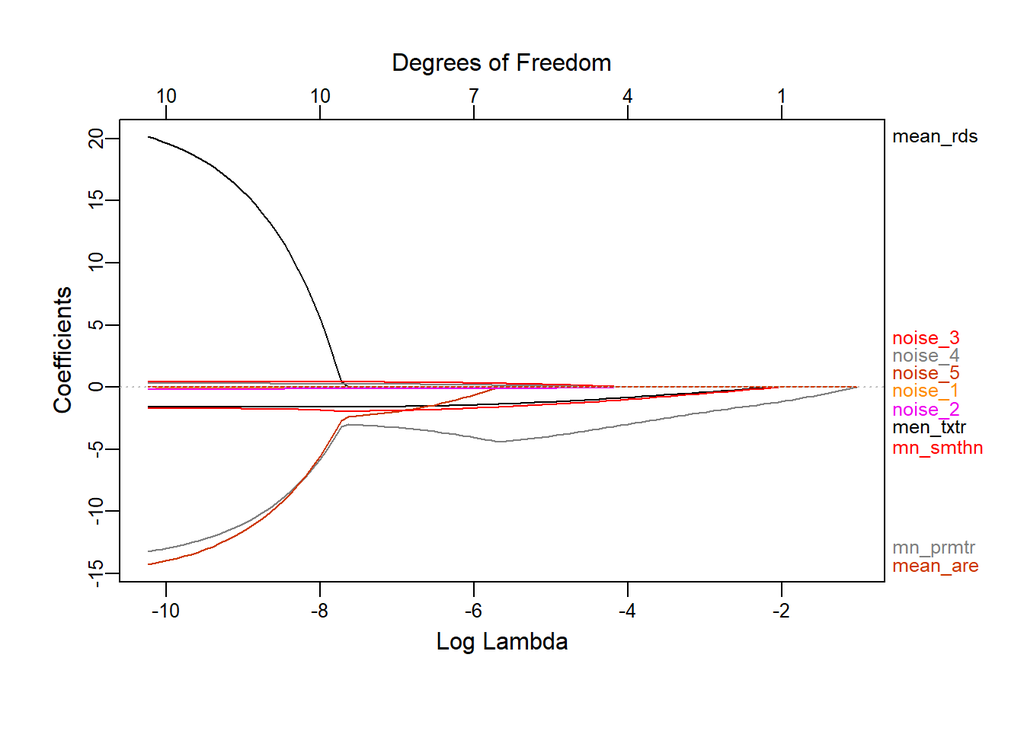

```r
# Create x variables
x_vars <- model.matrix(diagnosis ~.,
                       x_data)[,-1]
# Fit lasso model
lasso_fit <- glmnet(x = x_vars, # Set explantory variables
                    y = bc_data$diagnosis, # Set response variable
                    alpha = 1, # Set alpha value
                    family = "binomial")
plot_glmnet(lasso_fit, # Plot lasso coefficients by lambda
            xvar = "lambda")
```

```r
# Print coefficients
coef(lasso_fit)
```

```
## 11 x 100 sparse Matrix of class "dgCMatrix"
##
## (Intercept)     0.5211495  0.5232924  0.5283271  0.5348659  0.5421138
## mean_radius     .          .          .          .          .
## mean_texture    .          .          .          .          .
## mean_perimeter  .         -0.1350472 -0.2581069 -0.3733964 -0.4835571
## mean_area       .          .          .          .          .
## mean_smoothness .          .          .          .          .
## noise_1         .          .          .          .          .
## noise_2         .          .          .          .          .
## noise_3         .          .          .          .          .
## noise_4         .          .          .          .          .
## noise_5         .          .          .          .          .
##
## (Intercept)      0.5496069  0.5570689  0.5643309  0.5712866  0.577868
## mean_radius      .          .          .          .          .
## mean_texture     .          .          .          .          .
## mean_perimeter  -0.5902513 -0.6945306 -0.7970658 -0.8982912 -0.998493
## mean_area        .          .          .          .          .
## mean_smoothness  .          .          .          .          .
## noise_1          .          .          .          .          .
## noise_2          .          .          .          .          .
## noise_3          .          .          .          .          .
## noise_4          .          .          .          .          .
## noise_5          .          .          .          .          .
##
## (Intercept)      0.5840316  0.5897508  0.59434955  0.59847470  0.6031171
## mean_radius      .          .          .           .           .
## mean_texture     .          .          .          -0.04268590 -0.0876680
## mean_perimeter  -1.0978611 -1.1965205 -1.28819489 -1.35916455 -1.4308644
## mean_area        .          .          .           .           .
## mean_smoothness  .          .         -0.03138117 -0.08756428 -0.1420209
## noise_1          .          .          .           .           .
## noise_2          .          .          .           .           .
## noise_3          .          .          .           .           .
## noise_4          .          .          .           .           .
## noise_5          .          .          .           .           .
##
## (Intercept)      0.6082079  0.6136785  0.6194769  0.6255643  0.6319119
## mean_radius      .          .          .          .          .
```

[output cut: 210 more lines]

```
## noise_3           0.457806854   0.458453761   0.459046125   0.459597016
## noise_4           0.307626917   0.308288118   0.308887864   0.309440255
## noise_5           0.003452828   0.003944745   0.004386898   0.004793021
##
## (Intercept)      -0.325024996  -0.334967453
## mean_radius      19.973639947  20.150623869
## mean_texture     -1.576381680  -1.577286440
## mean_perimeter  -13.114007185 -13.204500328
## mean_area       -14.163563482 -14.271533967
## mean_smoothness  -1.706838352  -1.706161729
## noise_1          -0.013764243  -0.013663788
## noise_2          -0.147235331  -0.147549314
## noise_3           0.460107568   0.460572364
## noise_4           0.309947038   0.310405328
## noise_5           0.005164781   0.005498169
```

We can also select the lambda value to use using cross-validation :

```r
set.seed(123)
# Set sequence of lambda values
lambda_seq <- 10^seq(4, -4, by = -.1)
# Fit cross-validated lasso model
cv.lasso <- cv.glmnet(x = x_vars, # Set x variables
                 y = bc_data$diagnosis, # Set response variables
                 alpha = 1, # Set alpha = 1 for lasso
                 family = "binomial", # Set family as binomial for logistic regression
                 lambda = lambda_seq, # Set lambda values to try
                 nfolds = 10)
best_lam <- cv.lasso$lambda.1se # Extract best lambda
best_lam  # Print best lambda
```

```
## [1] 0.01
```

We can then fit a lasso logistic regression using the calculated lambda by setting the lambda parameter.

```r
lasso_fit_final <- glmnet(x = x_vars, # Set explantory variables
                    y = bc_data$diagnosis, # Set response variable
                    alpha = 1, # Set alpha as 1 for lasso
                    family = "binomial", # Set as logistic regression
                    lambda = best_lam) # Set lambda as best lambda
```

We can then compare our coefficients for both logistic and linear regression

```r
temp <- cbind.data.frame(coef(fit_15), as.vector(coef(lasso_fit_final))) # Join Coefficients from models
names(temp) <- c("logisitic Regression", "Logistic Lasso") # Name coefficient columns
rownames(temp) <- names(coef(fit_15)) # Add rownames to coefficients
temp # Print coefficients
```

```
##                 logisitic Regression Logistic Lasso
## (Intercept)              11.82266657     0.79741720
## mean_radius               6.37884106     0.00000000
## mean_texture             -0.36979222    -1.04545941
## mean_perimeter           -0.59046740    -3.56699038
## mean_area                -0.04475773     0.00000000
## mean_smoothness        -120.86614055    -1.23334508
## noise_1                  -0.01263626     0.00000000
## noise_2                  -0.15949743    -0.04650794
## noise_3                   0.49044688     0.14455555
## noise_4                   0.32782315     0.04445678
## noise_5                   0.01019389     0.00000000
```

When we apply the Lasso logistic regression model we see that the coefficients for mean radius and mean area are now zero, indicating that they do not play a large role in determining if a tumor is malignant or benign. The variables for texture, perimeter and smoothness all have non-zero negative coefficients indicating that low values for texture, perimeter and smoothness are more likely to indicate a malignant tumor.

# Assignment 2

For this analysis we will be using churn data. The dataset is stored as `churn_data.rda` which can be loaded in by running the below command if the file is located in your working directory or else by accessing the file through file->open file

```r
load("churn_data.rda") # Load churn dataset
```

We can view a summary of this dataset by running `summary()`:

```r
summary(churn_data)
```

```
##     gender          SeniorCitizen      Partner           Dependents
##  Length:7032        Min.   :0.0000   Length:7032        Length:7032
##  Class :character   1st Qu.:0.0000   Class :character   Class :character
##  Mode  :character   Median :0.0000   Mode  :character   Mode  :character
##                     Mean   :0.1624
##                     3rd Qu.:0.0000
##                     Max.   :1.0000
##      tenure      PhoneService       MultipleLines      InternetService
##  Min.   : 1.00   Length:7032        Length:7032        Length:7032
##  1st Qu.: 9.00   Class :character   Class :character   Class :character
##  Median :29.00   Mode  :character   Mode  :character   Mode  :character
##  Mean   :32.42
##  3rd Qu.:55.00
##  Max.   :72.00
##  OnlineSecurity     OnlineBackup       DeviceProtection   TechSupport
##  Length:7032        Length:7032        Length:7032        Length:7032
##  Class :character   Class :character   Class :character   Class :character
##  Mode  :character   Mode  :character   Mode  :character   Mode  :character
##
##
##
##  StreamingTV        StreamingMovies      Contract         PaperlessBilling
##  Length:7032        Length:7032        Length:7032        Length:7032
##  Class :character   Class :character   Class :character   Class :character
##  Mode  :character   Mode  :character   Mode  :character   Mode  :character
##
##
##
##  PaymentMethod      MonthlyCharges    TotalCharges        Churn
##  Length:7032        Min.   : 18.25   Min.   :  18.8   Min.   :0.0000
##  Class :character   1st Qu.: 35.59   1st Qu.: 401.4   1st Qu.:0.0000
##  Mode  :character   Median : 70.35   Median :1397.5   Median :0.0000
##                     Mean   : 64.80   Mean   :2283.3   Mean   :0.2658
##                     3rd Qu.: 89.86   3rd Qu.:3794.7   3rd Qu.:1.0000
##                     Max.   :118.75   Max.   :8684.8   Max.   :1.0000
```

The variables we have are:

- Gender - Whether the customer is a male or a female
- SeniorCitizen - Whether the customer is a senior citizen or not (1,0)
- Partner - Whether the customer has a partner or nor (Yes, No)
- Dependents - Whether the customer has dependents or not (Yes, No)
- tenure - Number of months the customer has stayed with the company
- PhoneService - Whether the customer has a phone service of no (Yes, No)
- MultipleLines - Whether the customer has multiple lines or not (Yes, No, No phone service)
- InternetService - Customer’s internet service provider (DSL, Fiber optic, No)
- OnlineSecurity - Whether the customer has online security or not (Yes, No, No internet service)
- OnlineBackup - Whether the customer has online backup or not (Yes, No, No internet service)
- DeviceProtection - Whether the customer has tech support or not (Yes, No, No internet service)
- StreamingTV - Whether the customer has streaming TV or not (Yes, No, No internet service)
- StreamingMovies - Whether the customer has streaming movies or not (Yes, No, No internet service)
- Contract - The contract term of the customer (Month-to-month, One year, Two year)
- PaperlessBilling - Whether the customer has paperless billing or not (Yes, No)
- PaymentMethod - The customer’s payment method (Electronic CHECK, Mailed check, Bank transfer (automatic), Credit card (automatic))
- MonthlyCharges - The amount charged to the customer monthly
- TotalCharges - The total amount charged to the customer
- Churn - Whether the customer churned or not (1 = Yes or 0 = No)

The response variable for this dataset is `Churn`:

```r
summary(as.factor(churn_data$Churn))
```

```
##    0    1
## 5163 1869
```

For the assignment please carry out the following tasks/answer the following questions: (12 Points)

- 1 - Create at least two visualizations potentially revealing factors with predictive power (2 Points)
- 2 - Fit a logistic regression model to the data. (Remember you can use `resp ~.,` to include all explanatory variables in the model) (2 Points)
- 3 - What features are significant in your logistic regression model? (1 Point)
- 4 - What is the AIC of your logistic regression model? (1 Point)
- 5 - Add an interaction term to the logistic regression model? (1 Point)
- 6 - Does the addition of the interaction term increase or decrease the AIC? What is the new AIC for the model? (1 Point)
- 7 - Fit a lasso logistic regression model to the data. (1 Point)
- 8 - Which coefficients were non-zero in the lasso model? Were they positive or negative? What does this imply? (1 Point)

2 Points for analysis decisions and code quality.

Please submit an an R-markdown document with the answers, optionally you can submit an R-script with the code used for your analysis and a document answering the specific questions, you can use word, pdf etc.

Assignments can be submitted via Canvas or by email to mbarron2@nd.edu.